# final_project

```python
#importing desired libraries

import numpy as np
import pandas as pd
from matplotlib import pyplot as plt
import seaborn as sns

from scipy import stats

from mpl_toolkits.mplot3d import Axes3D

from sklearn.feature_selection import SelectKBest
from sklearn.feature_selection import f_regression

from sklearn.model_selection import train_test_split

from sklearn.ensemble import RandomForestRegressor

from sklearn.cluster import KMeans
import random
```

```python
raw_data = pd.read_csv('pmsm_temperature_data.csv')
print(raw_data.columns)
print(raw_data.head(10))
print(raw_data.tail(10))
```

```
Index(['ambient', 'coolant', 'u_d', 'u_q', 'motor_speed', 'torque', 'i_d',
       'i_q', 'pm', 'stator_yoke', 'stator_tooth', 'stator_winding',
       'profile_id'],
      dtype='object')
    ambient   coolant       u_d       u_q  motor_speed    torque       i_d  \
0 -0.752143 -1.118446  0.327935 -1.297858    -1.222428 -0.250182  1.029572
1 -0.771263 -1.117021  0.329665 -1.297686    -1.222429 -0.249133  1.029509
2 -0.782892 -1.116681  0.332771 -1.301822    -1.222428 -0.249431  1.029448
3 -0.780935 -1.116764  0.333700 -1.301852    -1.222430 -0.248636  1.032845
4 -0.774043 -1.116775  0.335206 -1.303118    -1.222429 -0.248701  1.031807
5 -0.762936 -1.116955  0.334901 -1.303017    -1.222429 -0.248197  1.031031
6 -0.749228 -1.116170  0.335014 -1.302082    -1.222430 -0.247914  1.030493
7 -0.738450 -1.113986  0.336256 -1.305155    -1.222432 -0.248321  1.030107
8 -0.730910 -1.111828  0.334905 -1.303790    -1.222432 -0.247785  1.029851
9 -0.727130 -1.109486  0.335988 -1.305633    -1.222431 -0.248294  1.029636
```

[output cut: 47 more lines]

Columns description:

- ambient - ambient temperature
- coolant - motor coolant temperature
- u_d - voltage d-component
- u_q - voltage q-comonent
- motor_speed
- torque
- i_d - current d-component
- i_q - current q-compoent
- pm - permament magnet surface temperature (rotor temperautre) - to mozna modelowac
- stator_yoke - stator yoke temperature
- stator_tooth - stator tooth temperature
- stator_winding - stator winding temperature
- profile_id - measurement ID - powinno się podzielić set wg ID

```python
print(raw_data.describe())
```

```
             ambient        coolant            u_d            u_q  \
count  998070.000000  998070.000000  998070.000000  998070.000000
mean       -0.003905       0.004723       0.004780      -0.005690
std         0.993127       1.002423       0.997878       1.002330
min        -8.573954      -1.429349      -1.655373      -1.861463
25%        -0.599385      -1.037925      -0.826359      -0.927390
50%         0.266157      -0.177187       0.267542      -0.099818
75%         0.686675       0.650709       0.358491       0.852625
max         2.967117       2.649032       2.274734       1.793498

         motor_speed         torque            i_d            i_q  \
count  998070.000000  998070.000000  998070.000000  998070.000000
mean       -0.006336      -0.003333       0.006043      -0.003194
std         1.001229       0.997907       0.998994       0.997912
min        -1.371529      -3.345953      -3.245874      -3.341639
25%        -0.951892      -0.266917      -0.756296      -0.257269
50%        -0.140246      -0.187246       0.213935      -0.190076
75%         0.853584       0.547171       1.013975       0.499260
max         2.024164       3.016971       1.060937       2.914185

                  pm    stator_yoke   stator_tooth  stator_winding  \
count  998070.000000  998070.000000  998070.000000   998070.000000
mean       -0.004396       0.000609      -0.002208       -0.003935
std         0.995686       1.001049       0.999597        0.998343
min        -2.631991      -1.834688      -2.066143       -2.019973
25%        -0.672308      -0.747265      -0.761951       -0.725622
50%         0.094367      -0.057226       0.005085        0.006536
75%         0.680691       0.697344       0.772239        0.725660
max         2.917456       2.449158       2.326668        2.653781

          profile_id
count  998070.000000
mean       50.732001
std        22.073125
min         4.000000
25%        32.000000
50%        56.000000
75%        68.000000
max        81.000000
```

```python
print(raw_data.dtypes)
```

```
ambient           float64
coolant           float64
u_d               float64
u_q               float64
motor_speed       float64
torque            float64
i_d               float64
i_q               float64
pm                float64
stator_yoke       float64
stator_tooth      float64
stator_winding    float64
profile_id          int64
dtype: object
```

```python
raw_data.isna().sum()
```

```
ambient           0
coolant           0
u_d               0
u_q               0
motor_speed       0
torque            0
i_d               0
i_q               0
pm                0
stator_yoke       0
stator_tooth      0
stator_winding    0
profile_id        0
dtype: int64
```

As it can be seen, there are no missing data in the dataset

```python
# looking for outliers - first - sorting the data to see if there are any values
# much different from the neighboring ones

sorted = raw_data.sort_values(by = 'pm', ascending = True)
print(sorted.head())
sorted = raw_data.sort_values(by = 'pm', ascending = False)
print(sorted.head())
```

```
         ambient   coolant       u_d       u_q  motor_speed    torque  \
237100 -3.211671 -0.955446  0.347322 -1.283859    -1.222434 -0.247703
237101 -3.208099 -0.958988  0.336716 -1.256571    -1.213598 -0.242966
237096 -3.196879 -0.954569  0.349610 -1.276676    -1.222431 -0.246554
237097 -3.204384 -0.955393  0.350125 -1.276165    -1.222428 -0.246389
237099 -3.210306 -0.954502  0.348633 -1.280977    -1.222434 -0.247279

             i_d       i_q        pm  stator_yoke  stator_tooth  \
237100  1.029235 -0.245740 -2.631991    -1.783079     -2.038974
237101  1.024232 -0.208363 -2.631983    -1.782313     -2.038910
237096  1.029458 -0.245831 -2.631785    -1.785455     -2.041071
237097  1.029390 -0.245796 -2.631717    -1.785005     -2.040924
237099  1.029281 -0.245751 -2.631665    -1.783778     -2.039497

        stator_winding  profile_id
```

[output cut: 25 more lines]

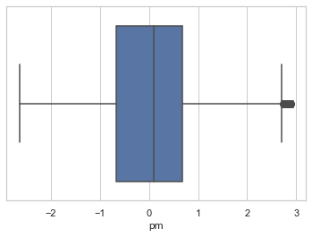

```python
# lookig for outliers - graphical(boxplot) method

sns.set(style="whitegrid")
sns.boxplot(x = raw_data['pm'])
plt.show()
```

```python
# lookig for outliers - sigma score method

z = np.abs(stats.zscore(raw_data['pm']))
print(np.where(z > 3 ))

z = np.abs(stats.zscore(raw_data ['pm']))
print(np.where(z > 3 ))
```

```
(array([], dtype=int64),)
(array([], dtype=int64),)
```

```python
# lookig for outliers - interquantile score IQR. The difference in the numbers
# printed below tells how many outliers we had

Q1 = raw_data['pm'].quantile(0.25)
Q3 = raw_data['pm'].quantile(0.75)


IQR = Q3 - Q1

mask = (raw_data['pm'] > (Q1 - 1.5 * IQR)) | (raw_data['pm'] < (Q3 + 1.5 * IQR))

#print(mask)

print(len(raw_data['pm']))
input = raw_data[mask] #dPower_kWeletes outliers - selects only true rows
print(len(raw_data['pm']))
```

```
998070
998070
```

```python
# Histogram of input data
def histogram(data):
    for i in data.columns:
        sns.distplot(data[i], bins= 30, hist = True, kde =False)

        plt.xlabel (str(i), fontsize = 12)  # create axes labels
        plt.ylabel ("Number of occurences", fontsize = 12)
        plt.xticks (fontsize = 12) # change the value and see what it is
        plt.yticks (fontsize = 12)

        plt.title ('Histogram for parameter: '+ str(i))
        plt.show()
```

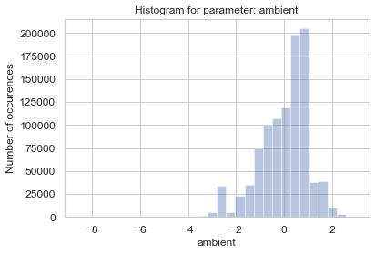

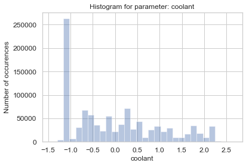

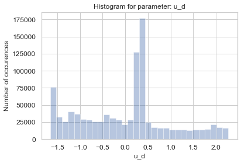

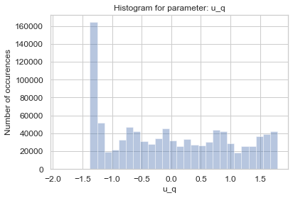

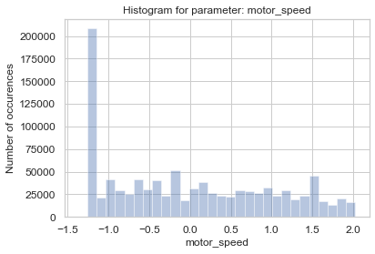

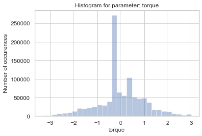

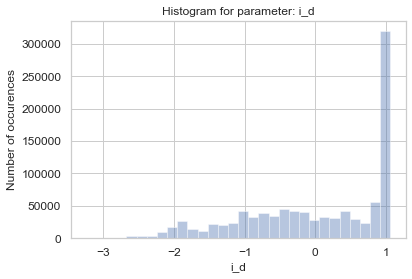

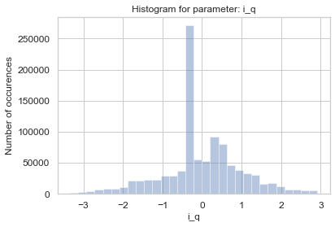

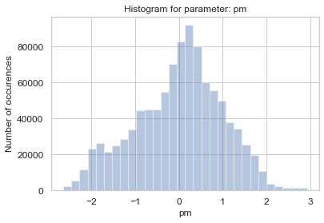

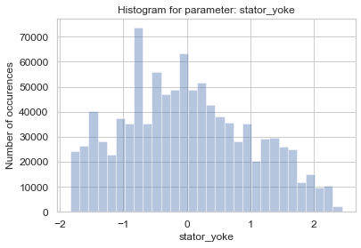

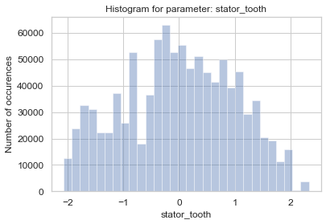

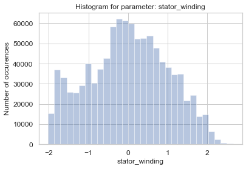

[1 more figures not shown]

```python
histogram(raw_data)
```

Clustering

```python
def cluster_fig(df, columns):

    fig = plt.figure()
    ax = fig.add_subplot(111, projection='3d')
    x = np.array(df[columns[0]])
    y = np.array(df[columns[1]])
    z = np.array(df[columns[2]])

    ax.scatter(x,y,z, marker="s", c=y_km, s=40, cmap="RdBu")

    ax.set_title('Clusteting result')
    ax.set_xlabel(str(columns[0]))
    ax.set_ylabel(str(columns[1]))
    ax.set_zlabel(str(columns[2]))

    plt.show()
```

```
[[-0.054472    1.16020942  0.73265453]
 [-0.79302541 -0.60426991 -0.45713486]
 [ 1.03219175 -0.48786    -0.23818643]]
[0 0 0 ... 0 0 0]
```

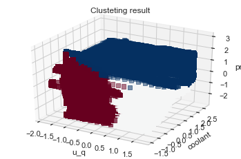

```python
# clustering start
#select 3 random columns from dataset
sel_columns = random.sample(list(raw_data.columns), 3)

# create kmeans object for randomly selected subset

kmeans = KMeans(n_clusters=3)
df = pd.DataFrame(raw_data,columns=sel_columns)
# fit kmeans object to data
kmeans.fit(df)
# print location of clusters learned by kmeans object
print(kmeans.cluster_centers_)
# save new clusters for chart
y_km = kmeans.fit_predict(df)
print(y_km)

cluster_fig(df, sel_columns)
```

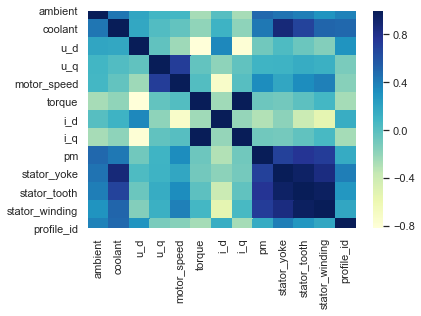

```python
#plotting correlation matrix
plot = sns.heatmap(raw_data.corr(), cmap="YlGnBu")
plt.show()
plot.figure.savefig("heatmap.png", bbox_inches='tight')
```

Feature engineering

```python
#jakis feature engineering chcemy?
raw_data['coolant^2'] = np.square(raw_data['coolant'])
raw_data['coolant^3'] = np.power(raw_data['coolant'], 3)

raw_data['ambient^2'] = np.square(raw_data['ambient'])
raw_data['ambient^3'] = np.power(raw_data['ambient'], 3)

raw_data['speed^2'] = np.square(raw_data['motor_speed'])
raw_data['speed^3'] = np.power(raw_data['motor_speed'], 3)
```

```python
print(raw_data.columns)
```

```
Index(['ambient', 'coolant', 'u_d', 'u_q', 'motor_speed', 'torque', 'i_d',
       'i_q', 'pm', 'stator_yoke', 'stator_tooth', 'stator_winding',
       'profile_id', 'coolant^2', 'coolant^3', 'ambient^2', 'ambient^3',
       'speed^2', 'speed^3'],
      dtype='object')
```

We decide to build models for permament magnet temperature and delete temperature measurements for other components such as: stator_yoke, stator_tooth, stator_winding

```python
to_drop = ['stator_yoke', 'stator_tooth', 'stator_winding']
raw_data = raw_data.drop(columns = to_drop)
```

```python
print(raw_data.columns)
```

```
Index(['ambient', 'coolant', 'u_d', 'u_q', 'motor_speed', 'torque', 'i_d',
       'i_q', 'pm', 'profile_id', 'coolant^2', 'coolant^3', 'ambient^2',
       'ambient^3', 'speed^2', 'speed^3'],
      dtype='object')
```

Now we need to split data into subsets following the profile id, meaning different measurements. We create dictionary containing created subsets grouped by the same profile id.

```python
profiles = raw_data['profile_id'].unique().tolist()

data_dict = {element: pd.DataFrame for element in profiles}
for key in data_dict.keys():
    data_dict[key] = raw_data[:][raw_data['profile_id'] == key]

print('Number of created subsets '+ str(len(profiles)))
```

```
Number of created subsets 52
```

Now, we check length of each created dataset to see if any of them are not representative enough for further modelling

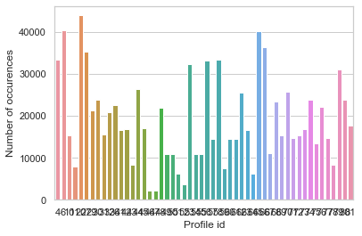

```python
lengths = {}
for key in data_dict.keys():
    lengths[key] = len(data_dict[key])
    #print('Subset with profile id: '+ str(key))
    #print(print(len(data_dict[key])))


sns.barplot(list(lengths.keys()), list(lengths.values()))
plt.xlabel ("Profile id", fontsize = 12)
plt.ylabel ("Number of occurences", fontsize = 12)
```

We will drop datasets that contain less than 10 k number of occurances

```python
print("Number of datasets before: " +str(len(data_dict)))
clean_dict = {k: v for k, v in data_dict.items() if len(v) >= 10000}
print("Number of datasets after: " +str(len(clean_dict)))
print("Number of datasets containing less than 10 k occurences: " +str(int(len(data_dict)) - int(len(clean_dict))))
```

```
Number of datasets before: 52
Number of datasets after: 43
Number of datasets containing less than 10 k occurences: 9
```

Feature Engineering

```python
# looking for the optimum number of k features for the model

print(clean_dict[4].columns)
```

```
Index(['ambient', 'coolant', 'u_d', 'u_q', 'motor_speed', 'torque', 'i_d',
       'i_q', 'pm', 'profile_id', 'coolant^2', 'coolant^3', 'ambient^2',
       'ambient^3', 'speed^2', 'speed^3'],
      dtype='object')
```

```python
def test_Kfeatures(data, dataX, dataY):
    features=SelectKBest(k='all',score_func=f_regression) #selecting all the features and checking which will return the highest performance
    fit=features.fit(dataX, dataY) #calculastes the f_regression of the features
    print(fit.scores_)
    features_results=fit.transform(dataX)
    print(features_results)

    chart = sns.barplot(x=data.drop(columns = ['pm']).columns, y =fit.scores_)
    chart.set_xticklabels(chart.get_xticklabels(), rotation=45, horizontalalignment='right')
    plt.title('Best feature scores for the dataset')
    plt.xlabel('Feature')
    plt.ylabel('Score')
    plt.show()
```

```python
# divide input values into datasets for modelling
data = clean_dict[4]
X= data.drop(columns=['pm']).values
Y= data['pm'].values
```

```
[   47.23947284  1850.79231318 12336.29949253   106.34183648
 20613.745699    1151.20674108 28032.27003579   645.20790058
            nan  1809.60150951  1768.79595573  2005.58551276
   914.11701777 13937.03956725 17252.51154521]
[[-0.75214297 -1.1184461   0.3279352  ... -0.4255016   1.4943307
  -1.82671199]
 [-0.77126324 -1.1170206   0.3296648  ... -0.45878361  1.49433339
  -1.82671692]
 [-0.78289163 -1.1166813   0.3327715  ... -0.47984939  1.49432973
  -1.8267102 ]
 ...
 [ 0.30321804 -1.0866203   0.31541803 ...  0.02787822  0.9060959
  -0.86250427]
 [ 0.30890322 -1.0850283   0.31534937 ...  0.02947592  0.90606449
  -0.86245941]
 [ 0.32668257 -1.0830811   0.31513104 ...  0.03486405  0.9060841
  -0.86248741]]
```

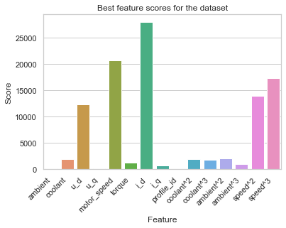

```python
test_Kfeatures(data, X, Y)
```

```
[2.77750719e-04 1.59862893e-03 2.46795285e-01 1.35254360e-01
 1.59313415e-04 3.95465857e-02 4.54365481e-01 1.14879162e-01
 0.00000000e+00 2.54881471e-03 1.22122004e-03 1.52979779e-03
 2.68404521e-04 1.40793007e-03 1.47265704e-04]
```

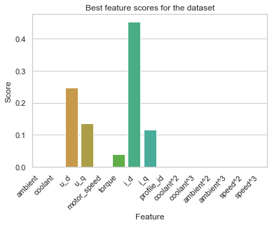

```python
# randomforest method - ensemble - for most important features

model = RandomForestRegressor()
model.fit(X, Y)
print(model.feature_importances_)

chart = sns.barplot(x=data.drop(columns = ['pm']).columns, y = model.feature_importances_)
chart.set_xticklabels(chart.get_xticklabels(), rotation=45, horizontalalignment='right')
plt.title('Best feature scores for the dataset')
plt.xlabel('Feature')
plt.ylabel('Score')
plt.show()
```

according to RFR, the best features are:

```
- u_d
- u_q
- torque
- i_d
- i_q
```

Those parameters will be used in the further modelling process

```python
data = data.drop(columns = ['ambient', 'coolant', 'motor_speed', 'coolant^2', 'coolant^3', 'ambient^2', 'ambient^3',
                           'speed^2', 'speed^3'])
```

Trying to do feature engineering with remaining features

```python
print(data)
```

```
            u_d       u_q    torque       i_d       i_q        pm  profile_id
0      0.327935 -1.297858 -0.250182  1.029572 -0.245860 -2.522071           4
1      0.329665 -1.297686 -0.249133  1.029509 -0.245832 -2.522418           4
2      0.332771 -1.301822 -0.249431  1.029448 -0.245818 -2.522673           4
3      0.333700 -1.301852 -0.248636  1.032845 -0.246955 -2.521639           4
4      0.335206 -1.303118 -0.248701  1.031807 -0.246610 -2.521900           4
...         ...       ...       ...       ...       ...       ...         ...
33418  0.315579 -0.708670 -0.255931  1.029120 -0.245731 -2.027046           4
33419  0.315788 -0.708644 -0.256015  1.029162 -0.245710 -2.027100           4
33420  0.315418 -0.708799 -0.256042  1.029140 -0.245723 -2.028079           4
33421  0.315349 -0.709161 -0.256056  1.029118 -0.245730 -2.028595           4
33422  0.315131 -0.708598 -0.256077  1.029154 -0.245709 -2.028761           4

[33423 rows x 7 columns]
```

```python
#splitting dataset again
print(data.columns)
X= data.drop(columns=['pm', 'profile_id']).values
Y= data['pm'].values
```

```
Index(['u_d', 'u_q', 'torque', 'i_d', 'i_q', 'pm', 'profile_id'], dtype='object')
```

```
[0.24562022 0.14002035 0.03987777 0.45605254 0.11842913]
```

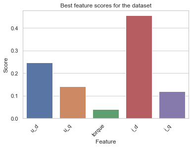

```python
# randomforest method - ensemble - for most important features

model = RandomForestRegressor()
model.fit(X, Y)
print(model.feature_importances_)

chart = sns.barplot(x=data.drop(columns = ['pm', 'profile_id']).columns, y = model.feature_importances_)
chart.set_xticklabels(chart.get_xticklabels(), rotation=45, horizontalalignment='right')
plt.title('Best feature scores for the dataset')
plt.xlabel('Feature')
plt.ylabel('Score')
plt.show()
```

Building regression model

```python
#divide input values into datasets for modelling
X= data.drop(columns=['pm', 'profile_id']).values
Y= data['pm'].values
```

```python
from sklearn.ensemble import RandomForestRegressor
from sklearn import  metrics
#by default, it chooses randomly 75% of the data for training and 25% for testing
X_train, X_test, y_train, y_test = train_test_split(X,Y)
print(X_train)
print(y_train)
```

```
[[-1.2459291   0.48464993  0.28755262 -1.3577037   0.23529127]
 [-1.492143   -0.06602354  1.9657506  -0.9210638   1.893773  ]
 [ 0.30086318  0.9597265  -0.2592871   1.0291337  -0.2457195 ]
 ...
 [ 0.30117157  0.96159095 -0.25897488  1.0291348  -0.24570127]
 [-1.2561697   0.466979    0.28982955 -1.3555347   0.23584552]
 [ 0.3005688   0.9602262  -0.2591902   1.0291696  -0.24571921]]
[ 1.074544  -0.9752796 -1.8496312 ... -1.8479166  1.2860439 -1.8537916]
```

```python
parameters = {'bootstrap': True,
              'min_samples_leaf': 3,
              'n_estimators': 100,
              'min_samples_split': 15,
              'max_features': 'sqrt',
              'max_depth': 10,
              'max_leaf_nodes': None}
RF_model = RandomForestRegressor(**parameters)
RF_model.fit(X_train, y_train)
y_pred_RF = RF_model.predict(X_test)
```

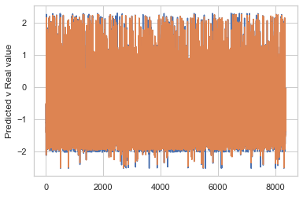

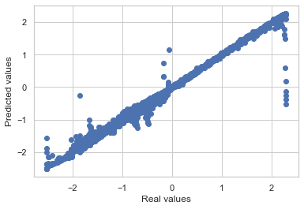

```python
plt.plot(y_test)
plt.ylabel('Predicted v Real value')
plt.plot(y_pred_RF)
plt.show()
plt.scatter(y_test,y_pred_RF)
plt.xlabel('Real values')
plt.ylabel('Predicted values')
```

Performance metrics

```python
#Evaluate errors
MAE = metrics.mean_absolute_error(y_test,y_pred_RF)
MSE = metrics.mean_squared_error(y_test,y_pred_RF)
RMSE = np.sqrt(metrics.mean_squared_error(y_test,y_pred_RF))
cvRMSE = RMSE/np.mean(y_test)
print("The following performance results are:")
print("Mean absolute error: " +str(MAE))
print("Mean squared error: " +str(MSE))
print("Root mean squared error: " +str(RMSE))
print("Coefficient of Variation of RMSE " +str(cvRMSE))
```

```
The following performance results are:
Mean absolute error: 0.03310941230447029
Mean squared error: 0.00791557284080279
Root mean squared error: 0.08896950511721861
Coefficient of Variation of RMSE -0.10607914845804657
```